# Who Will Ride the New Lines?

Station-level ridership prediction for the Jurong Region Line and Cross Island Line Phase 1 using probabilistic spatial interaction models

Zhiyi Hao

2026-11-11

## Contents

## 01 · Research questionWill the new stations be busy, or the next Hume?

Can a probabilistic spatial interaction model, calibrated on observed tap-ins, forecast ridership at the **29 new JRL and CRL1 stations**, and show which **existing stations lose riders** to them?

36 JRL (24) and CRL Phase 1 (12) stations, opening 2028–2030

29 + 7 genuinely new stations + existing stations upgraded to interchanges

9.8M weekday morning-peak tap-ins (May 2022) used to calibrate the model

164 × 286 stations × resident subzones in the choice model

**Why it matters.** Hume station stood finished but closed for a decade, and Buangkok and Woodleigh stayed shut when the NEL opened, because expected ridership could not cover operating costs. Planners need station-level forecasts *before* the trains run.

## 02 · Study area and dataOne network, five data traps cleared

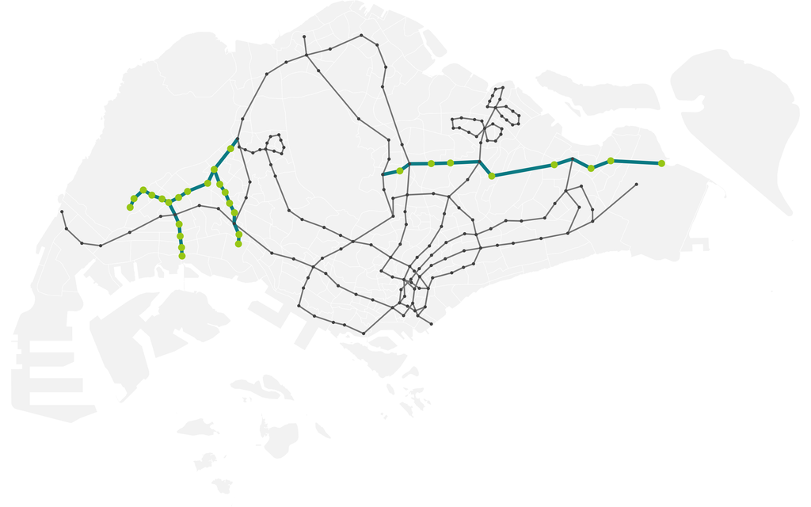

May 2022 network (grey) and JRL / CRL1 extensions (teal) with the 29 new stations (green)

Inputs

- LTA **OD train flows** (May 2022), **bus stops**, **station exits**
- **Census 2020** population; **HDB** footprints; **OSM POIs**
- URA **MP2025 stations**, **MP2019 land use**; JRL/CRL1 list

Data traps found and cleared

- 5 stations **missing X/Y**; Rochor’s lat/long ~480 m off its exits
- 3 non-operational codes, incl. **Bukit Brown, a real ghost station**
- URA layer suggests **98 “new” stations**; only 29 are
- LTA shapefiles with **no EPSG code** (custom “SVY21”)

## 03 · Analytical approachFrom tap-ins to a station-choice model

1 Clean & build Audit five data sources; build origin, destination and two spatial interaction data frames. → 286 origins × 164 / 193 stations

2 Flow models (SIM) Poisson unconstrained → doubly constrained models on station-to-station flows, network distance. → distance elasticity -0.93

3 Huff calibration Residents choose a station by attraction (lines, LRT) and access distance; tested against two benchmarks. → R² 0.80, CV R² 0.79

4 2030 scenario Add 29 stations, upgrade 7 interchanges; re-run with `MCI::huff.shares()`; Tengah build-out test. → forecasts & market areas

5 Value-added **MCI destination-choice model** (alternative probabilistic SIM) for alightings; LISA on residuals; KD2SFCA access. → destination demand, bias, equity

**Demand** · weekday 06:00–09:59 tap-ins **Attraction** · lines served γ = 1.29, LRT δ = -1.47 **Decay** · exponential λ = 2.16 per km **Calibration** · optim() on RMSE, 5-fold CV **Software** · R: sf, MCI, igraph, spdep, SpatialAcc, tmap

**Key modelling choice.** Exponential decay beat the course-default power function (R² 0.80 vs 0.74). The power curve’s long tail let stations 5 km away compete for residents, which spread scenario impacts unrealistically across the whole island.

## 04 · Key findingsFinding 1: The model reproduces where Singapore boards

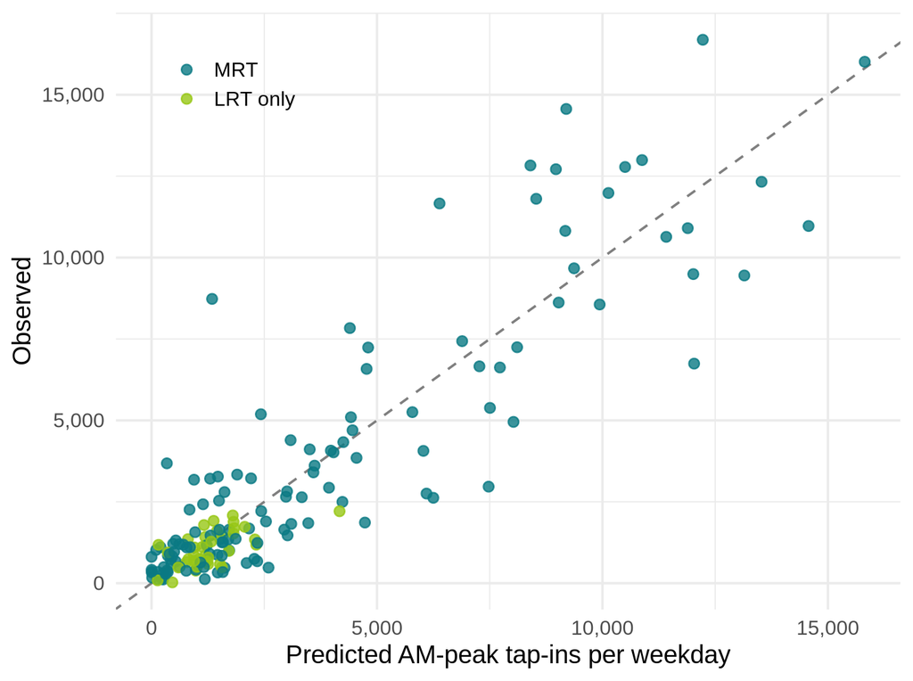

0.80 **R²** for 164 stations, vs 0.44 for nearest-station allocation and 0.48 for the default Huff model

0.79 **out-of-sample R²** (5-fold cross-validation): parameters are stable, not over-fitted

−66% **attractiveness per extra 500 m** of access distance: residents choose the station they can walk to

## 04 · Key findingsFinding 2: Count both ends of the trip, not just boardings

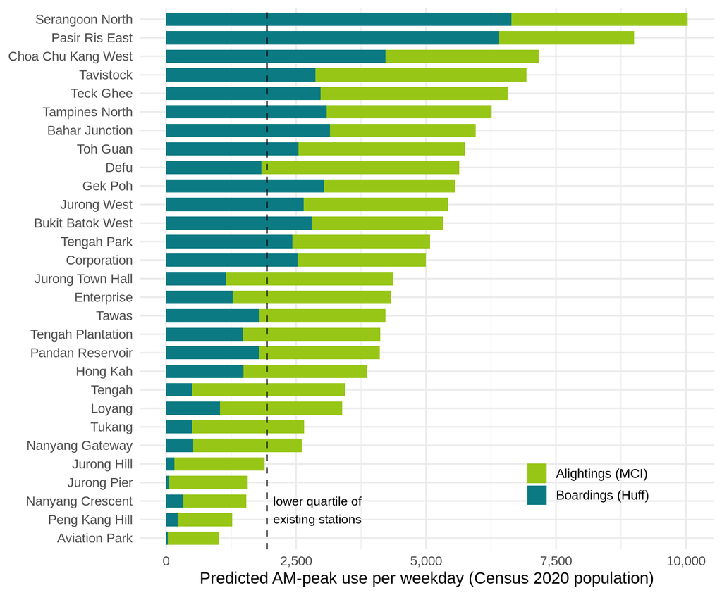

Strongest new stations

**Serangoon North, Pasir Ris East, Choa Chu Kang West**, inserted into mature HDB estates beyond walking distance of MRT today, would rank in the **top quarter** of existing stations.

Value-added: MCI destination model

**Genuine opening-day risks:** Aviation Park, Peng Kang Hill, Nanyang Crescent, Jurong Pier, Jurong Hill: redeveloping industrial land, NTU campus and airport logistics.

## 04 · Key findingsFinding 3: Tengah’s stations depend on housing, not rails

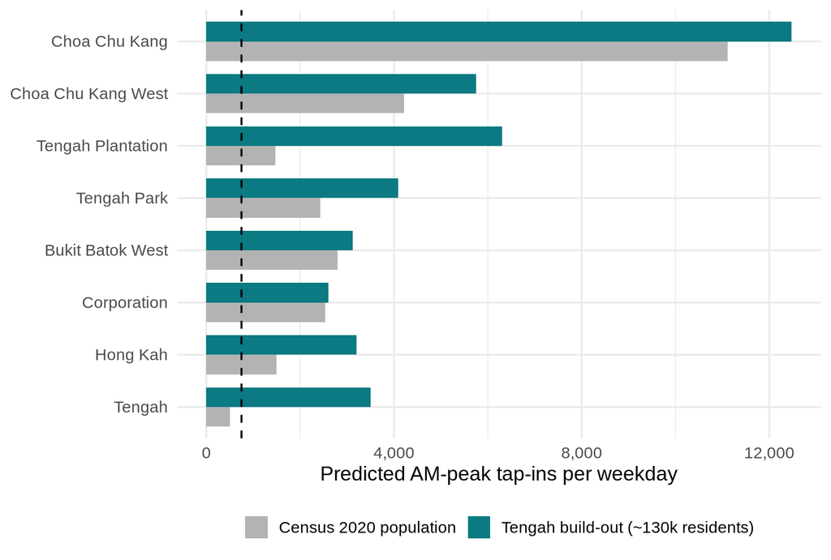

503 → 3,502 **Tengah (JS3)** morning tap-ins per weekday, from 2020 population to full build-out (42,000 homes)

×4.3 **Tengah Plantation (JE1)**, which becomes one of the JRL’s busiest stations

**The Hume lesson in numbers.** Whether a JRL station is a white elephant depends on **when homes are occupied relative to opening day**. The model can set a completion threshold for opening each station.

## 04 · Key findingsFinding 4: Losses are local, and upgrades do not guarantee growth

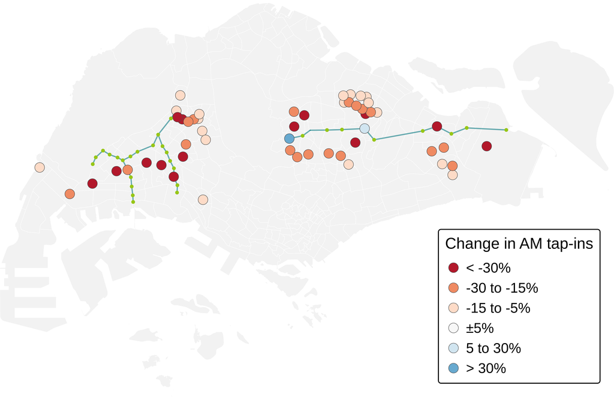

Existing stations changing by 5% or more once JRL and CRL1 open (Census 2020 population)

11% of morning boardings move to the new stations; **32** existing stations lose 15% or more, in three clusters next to the new lines

Hardest hit

The interchange paradox

Ang Mo Kio, Hougang, Bright Hill gain; **Boon Lay, Choa Chu Kang, Jurong East, Pasir Ris** lose tap-ins despite the extra line, while transfer crowding still rises.

## 04 · Key findingsFinding 5: Market areas shift locally; access gains go to the least served

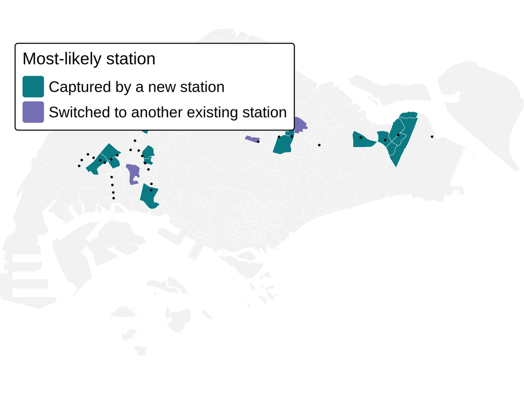

Subzones whose most-likely boarding station changes

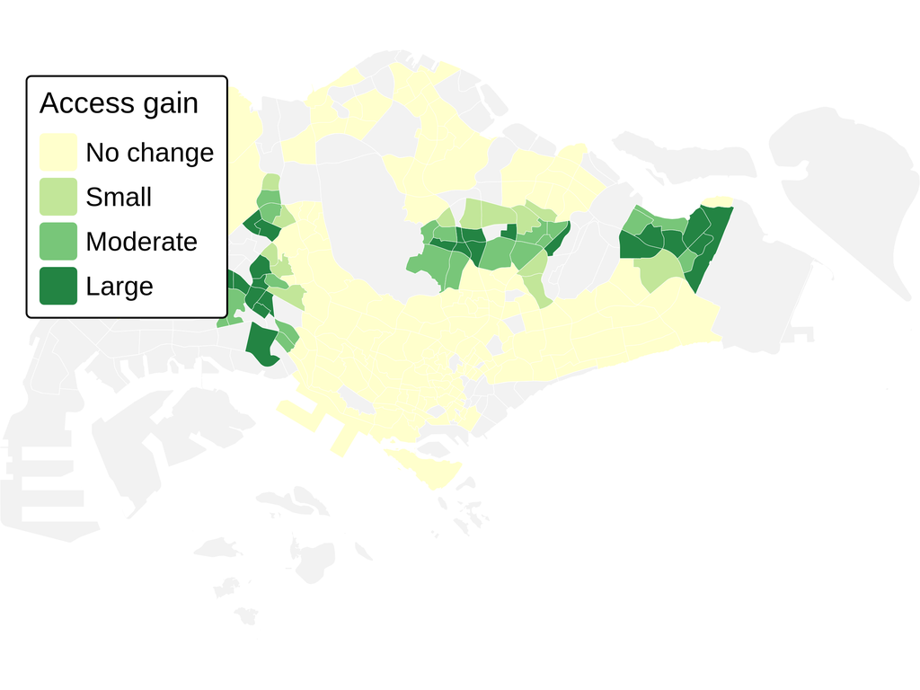

KD2SFCA rail accessibility gain (2 km catchment)

26 subzones (342k residents) gain a **new** most-likely station; the rest of the island is unchanged

63% vs 1% of residents gaining access in the **least** vs **best** served quintile (ρ = -0.43): the lines **narrow** the access gap

## 05 · Planning implicationsTurning forecasts into decisions

| Evidence | Recommended response | Why |
| --- | --- | --- |
| Tengah stations below the ghost-risk line on 2020 population JS3 Tengah, JE1 Tengah Plantation | Tie opening to housing completion thresholds | Forecast boardings rise several-fold at build-out; opening day matters more than the line itself. |
| Western EWL and Kovan–Serangoon belt lose 15%+ Pioneer, Lakeside, Chinese Garden, Kovan | Re-draw feeder-bus routes around new market areas | Avoid bus kilometres that duplicate the new rail catchments. |
| Seven upgraded interchanges Jurong East, Boon Lay, Hougang, Ang Mo Kio … | Plan platform and transfer-corridor capacity | Transfers are invisible in tap-ins but rise at every interchange. |
| Destination stations with low home-based boardings Tukang, Enterprise, Nanyang Gateway, Tengah | Appraise on boardings + alightings, not boardings alone | The MCI model shows workers and students arriving keep most of them above the ghost-risk line. |
| Model over-predicts in the east (LISA) Pasir Ris East, Tampines North, Loyang | Treat eastern forecasts as upper bounds | Residuals cluster significantly (Moran's I = 0.17, p = 0.001). |

Forecasts are a **comparative screening tool**: they rank stations and locate impacts reliably, while absolute numbers should be refreshed with current population and opening-day service plans.

## 06 · LimitationsWhat the forecasts can and cannot support

Data

- OD flows (May 2022) and population (Census 2020) pre-date the 2028–2030 network.
- Tap-ins miss **transfers** and **non-resident** demand (e.g. cross-border commuters); land use is a proxy for jobs.
- New-station locations are indicative Master Plan footprints.

Method

- Fixed trip rate: no **induced demand**; new boardings are diverted from existing stations.
- Attraction uses only lines and LRT status; feeder buses and frequency are missing.
- Straight-line access distance, not walking-network distance.

Interpretation

- Forecasts are **home-end morning boardings**, not total station use.
- Residuals cluster regionally, so eastern forecasts are likely optimistic.
- Rankings are robust to parameter uncertainty; absolute values are indicative.

**Reproducible workflow.** The Quarto technical report runs end-to-end with a fixed seed (626) and documents every data trap, parameter and modelling decision.  
**Technical report:** Who Will Ride the New Lines? · **Code:** github.com/sabrinahao99/ISSS626-GEO